# CMPINF 2100: Final exam - Models and Performance

## VASANTH MADHAVAN SRINIVASA RAGHAVAN

First Name: VASANTH MADHAVAN | Last Name: SRINIVASA RAGHAVAN

```python
import numpy as np
import pandas as pd
import matplotlib.pyplot as plt

import seaborn as sns

from sklearn.cluster import KMeans
from sklearn.preprocessing import StandardScaler
from sklearn.decomposition import PCA
from scipy.cluster import hierarchy
import statsmodels.formula.api as smf\

from sklearn.linear_model import LogisticRegression
from sklearn.metrics import confusion_matrix
from sklearn.metrics import roc_curve
from sklearn.metrics import roc_auc_score
from sklearn.model_selection import StratifiedKFold
```

```python
sns.set_palette("colorblind")
```

## Data Preparation

Following actions are taken based on exploratory data analysis. Please check the **EDA notebook** ipynb|html for additional details.

```python
songs_url = 'https://raw.githubusercontent.com/rfordatascience/tidytuesday/master/data/2020/2020-01-21/spotify_songs.csv'

df = pd.read_csv(songs_url)
```

```python
df.shape
```

```
(32833, 23)
```

```python
df.info()
```

```
<class 'pandas.core.frame.DataFrame'>
RangeIndex: 32833 entries, 0 to 32832
Data columns (total 23 columns):
 #   Column                    Non-Null Count  Dtype
---  ------                    --------------  -----
 0   track_id                  32833 non-null  object
 1   track_name                32828 non-null  object
 2   track_artist              32828 non-null  object
 3   track_popularity          32833 non-null  int64
 4   track_album_id            32833 non-null  object
 5   track_album_name          32828 non-null  object
 6   track_album_release_date  32833 non-null  object
 7   playlist_name             32833 non-null  object
 8   playlist_id               32833 non-null  object
 9   playlist_genre            32833 non-null  object
 10  playlist_subgenre         32833 non-null  object
 11  danceability              32833 non-null  float64
 12  energy                    32833 non-null  float64
 13  key                       32833 non-null  int64
 14  loudness                  32833 non-null  float64
 15  mode                      32833 non-null  int64
 16  speechiness               32833 non-null  float64
 17  acousticness              32833 non-null  float64
 18  instrumentalness          32833 non-null  float64
 19  liveness                  32833 non-null  float64
 20  valence                   32833 non-null  float64
 21  tempo                     32833 non-null  float64
 22  duration_ms               32833 non-null  int64
dtypes: float64(9), int64(4), object(10)
memory usage: 5.8+ MB
```

```python
df.nunique()
```

```
track_id                    28356
track_name                  23449
track_artist                10692
track_popularity              101
track_album_id              22545
track_album_name            19743
track_album_release_date     4530
playlist_name                 449
playlist_id                   471
playlist_genre                  6
playlist_subgenre              24
danceability                  822
energy                        952
key                            12
loudness                    10222
mode                            2
speechiness                  1270
acousticness                 3731
instrumentalness             4729
liveness                     1624
valence                      1362
tempo                       17684
duration_ms                 19785
dtype: int64
```

```python
df.dtypes
```

```
track_id                     object
track_name                   object
track_artist                 object
track_popularity              int64
track_album_id               object
track_album_name             object
track_album_release_date     object
playlist_name                object
playlist_id                  object
playlist_genre               object
playlist_subgenre            object
danceability                float64
energy                      float64
key                           int64
loudness                    float64
mode                          int64
speechiness                 float64
acousticness                float64
instrumentalness            float64
liveness                    float64
valence                     float64
tempo                       float64
duration_ms                   int64
dtype: object
```

### Create a target variable - track_populairy_bin (y)

```python
# Create a target variable - track_populairy_bin (y)

df['track_popularity_bin'] = np.where( df.track_popularity > 50, 1, 0 )
df = df.astype({'track_popularity_bin': 'object'})
df.track_popularity_bin.value_counts(normalize=True)
```

```
track_popularity_bin
0    0.574757
1    0.425243
Name: proportion, dtype: float64
```

### Data Cleanup

```python
#  Removing duplicates - More details in the EDA notebook

df.drop_duplicates(subset=['track_id'], keep='first', inplace=True)
df.info()
```

```
<class 'pandas.core.frame.DataFrame'>
Index: 28356 entries, 0 to 32832
Data columns (total 24 columns):
 #   Column                    Non-Null Count  Dtype
---  ------                    --------------  -----
 0   track_id                  28356 non-null  object
 1   track_name                28352 non-null  object
 2   track_artist              28352 non-null  object
 3   track_popularity          28356 non-null  int64
 4   track_album_id            28356 non-null  object
 5   track_album_name          28352 non-null  object
 6   track_album_release_date  28356 non-null  object
 7   playlist_name             28356 non-null  object
 8   playlist_id               28356 non-null  object
 9   playlist_genre            28356 non-null  object
```

[output cut: 16 more lines]

```python
# Remove identifier columns

df.drop(['track_id','track_album_id','playlist_id','track_artist','playlist_name', 'track_name', 'track_album_name'],
        inplace=True,
        axis=1)
```

```python
# Remove `playlist_subgenre` as it is high correlated with `playlist_genre`

df.drop(columns=['playlist_subgenre'], inplace=True)
```

```python
# Drop `track_album_release_date`

df.drop(columns=['track_album_release_date'], inplace=True)
```

### Addressing Skewness

```python
df_features = df.select_dtypes('number').copy()
df_features.drop(['track_popularity'], axis=1, inplace=True)
```

```python
df_objects = df.select_dtypes('object').copy()
```

```python
id_cols = ['rowid', 'track_popularity'] + df_objects.columns.to_list()
```

```python
df_lf = df.reset_index().\
rename(columns={'index': 'rowid'}).\
melt(id_vars=id_cols, value_vars=df_features.columns)
```

```python
df_lf
```

|  | rowid | track_popularity | playlist_genre | track_popularity_bin | variable | value |
| --- | --- | --- | --- | --- | --- | --- |
| 0 | 0 | 66 | pop | 1 | danceability | 0.748 |
| 1 | 1 | 67 | pop | 1 | danceability | 0.726 |
| 2 | 2 | 70 | pop | 1 | danceability | 0.675 |
| 3 | 3 | 60 | pop | 1 | danceability | 0.718 |
| 4 | 4 | 69 | pop | 1 | danceability | 0.650 |
| ... | ... | ... | ... | ... | ... | ... |
| 340267 | 32828 | 42 | edm | 0 | duration_ms | 204375.000 |
| 340268 | 32829 | 20 | edm | 0 | duration_ms | 353120.000 |
| 340269 | 32830 | 14 | edm | 0 | duration_ms | 210112.000 |
| 340270 | 32831 | 15 | edm | 0 | duration_ms | 367432.000 |
| 340271 | 32832 | 27 | edm | 0 | duration_ms | 337500.000 |

340272 rows × 6 columns

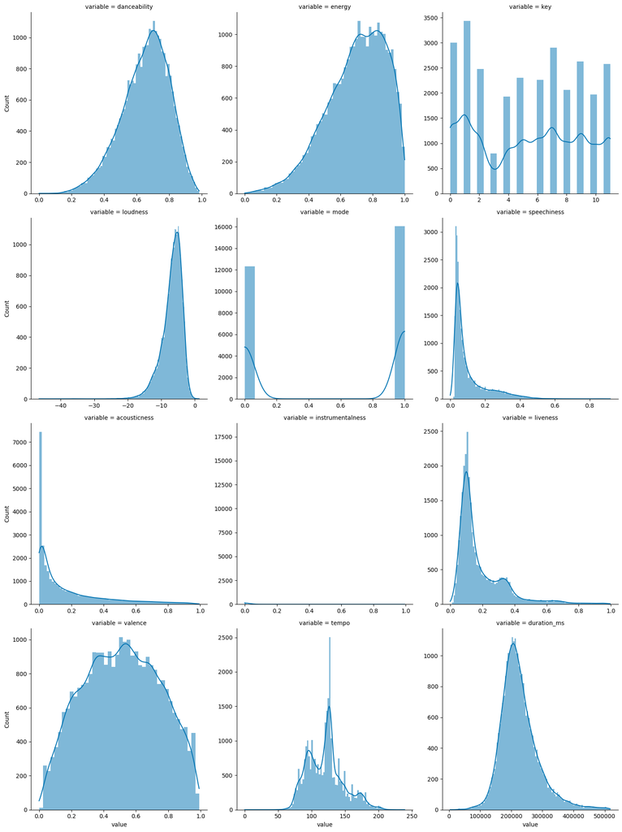

```python
sns.displot(data = df_lf, x='value', col='variable', kind='hist', kde=True,
            facet_kws={'sharex': False, 'sharey': False},
            common_bins=False,
            col_wrap=3)
plt.subplots_adjust(hspace=0.5)
plt.tight_layout()
plt.tight_layout()
plt.show()
```

```python
# Reducing skewness by applying log transform

df['speechiness_log'] = df['speechiness'].apply(lambda x: np.log(x) if x > 0 else 0)
df['acousticness_log'] = df['acousticness'].apply(lambda x: np.log(x) if x > 0 else 0)
df['instrumentalness_log'] = df['instrumentalness'].apply(lambda x: np.log(x) if x > 0 else 0)
df['liveness_log'] = df['liveness'].apply(lambda x: np.log(x) if x > 0 else 0)
df['duration_ms_log'] = df['duration_ms'].apply(lambda x: np.log(x) if x > 0 else 0)
```

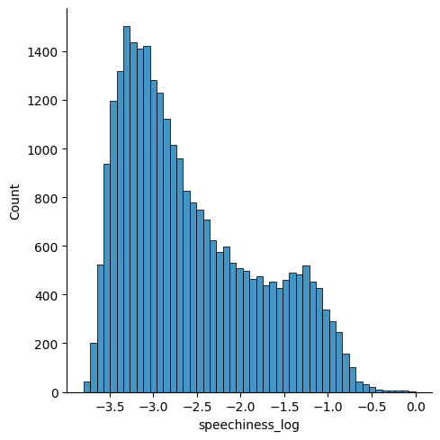

```python
sns.displot(data = df, x='speechiness_log', kind='hist')

plt.show()
```

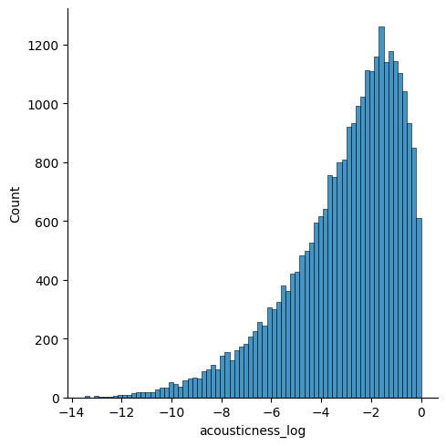

```python
sns.displot(data = df, x='acousticness_log', kind='hist')

plt.show()
```

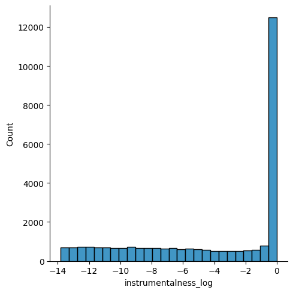

```python
sns.displot(data = df, x='instrumentalness_log', kind='hist')

plt.show()
```

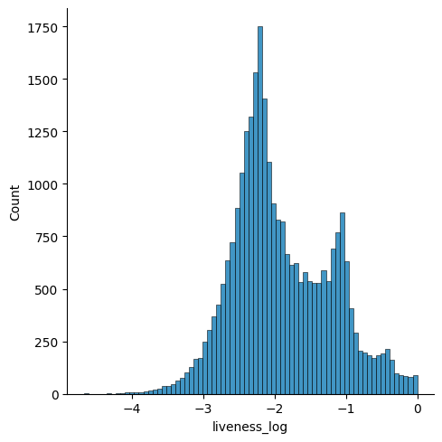

```python
sns.displot(data = df, x='liveness_log', kind='hist')

plt.show()
```

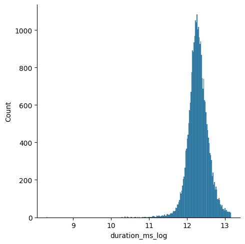

```python
sns.displot(data = df, x='duration_ms_log', kind='hist')

plt.show()
```

## D. Models: Fitting and Interpretation

### Fitting

Define a function to FIT and CALCULATE the training set performance

```python
def fit_and_assess_logistic(mod_name, a_formula, train_data, threshold):
    a_mod = smf.logit(formula=a_formula, data=train_data).fit()

    train_copy = train_data.copy()

    train_copy['pred_probability'] = a_mod.predict(train_data)

    train_copy['pred_class'] = np.where(train_copy.pred_probability > threshold, 1, 0 )

    TN, FP, FN, TP = confusion_matrix(train_copy.y.to_numpy(), train_copy.pred_class.to_numpy() ).ravel()

    Accuracy = (TN + TP) / (TN + FP + FN + TP)

    Sensitivity = (TP) / (TP + FN)

    Specificity = (TN) / (TN + FP)

    FPR = 1 - Specificity

    ROC_AUC = roc_auc_score(train_copy.y.to_numpy(), train_copy.pred_probability.to_numpy() )

    res_dict = {'model_name': mod_name,
                'model_formula': a_formula,
                'num_coefs': len( a_mod.params ),
                'threshold': threshold,
                'Accuracy': Accuracy,
                'Sensitivity': Sensitivity,
                'Specificity': Specificity,
                'FPR': FPR,
                'ROC_AUC': ROC_AUC}

    return pd.DataFrame( res_dict, index=[0] )
```

```python
df['y'] = df['track_popularity_bin']
df = df.astype({'y': 'int'})
```

```python
df.drop(columns=['track_popularity_bin', 'track_popularity'], inplace=True)
df
```

|  | playlist_genre | danceability | energy | key | loudness | mode | speechiness | acousticness | instrumentalness | liveness | valence | tempo | duration_ms | speechiness_log | acousticness_log | instrumentalness_log | liveness_log | duration_ms_log | y |
| --- | --- | --- | --- | --- | --- | --- | --- | --- | --- | --- | --- | --- | --- | --- | --- | --- | --- | --- | --- |
| 0 | pop | 0.748 | 0.916 | 6 | -2.634 | 1 | 0.0583 | 0.102000 | 0.000000 | 0.0653 | 0.5180 | 122.036 | 194754 | -2.842153 | -2.282782 | 0.000000 | -2.728763 | 12.179493 | 1 |
| 1 | pop | 0.726 | 0.815 | 11 | -4.969 | 1 | 0.0373 | 0.072400 | 0.004210 | 0.3570 | 0.6930 | 99.972 | 162600 | -3.288762 | -2.625549 | -5.470293 | -1.030019 | 11.999048 | 1 |
| 2 | pop | 0.675 | 0.931 | 1 | -3.432 | 0 | 0.0742 | 0.079400 | 0.000023 | 0.1100 | 0.6130 | 124.008 | 176616 | -2.600991 | -2.533257 | -10.667057 | -2.207275 | 12.081733 | 1 |
| 3 | pop | 0.718 | 0.930 | 7 | -3.778 | 1 | 0.1020 | 0.028700 | 0.000009 | 0.2040 | 0.2770 | 121.956 | 169093 | -2.282782 | -3.550858 | -11.571614 | -1.589635 | 12.038204 | 1 |
| 4 | pop | 0.650 | 0.833 | 1 | -4.672 | 1 | 0.0359 | 0.080300 | 0.000000 | 0.0833 | 0.7250 | 123.976 | 189052 | -3.327018 | -2.521986 | 0.000000 | -2.485307 | 12.149777 | 1 |
| ... | ... | ... | ... | ... | ... | ... | ... | ... | ... | ... | ... | ... | ... | ... | ... | ... | ... | ... | ... |
| 32828 | edm | 0.428 | 0.922 | 2 | -1.814 | 1 | 0.0936 | 0.076600 | 0.000000 | 0.0668 | 0.2100 | 128.170 | 204375 | -2.368725 | -2.569158 | 0.000000 | -2.706052 | 12.227712 | 0 |
| 32829 | edm | 0.522 | 0.786 | 0 | -4.462 | 1 | 0.0420 | 0.001710 | 0.004270 | 0.3750 | 0.4000 | 128.041 | 353120 | -3.170086 | -6.371262 | -5.456141 | -0.980829 | 12.774563 | 0 |
| 32830 | edm | 0.529 | 0.821 | 6 | -4.899 | 0 | 0.0481 | 0.108000 | 0.000001 | 0.1500 | 0.4360 | 127.989 | 210112 | -3.034473 | -2.225624 | -13.711151 | -1.897120 | 12.255396 | 0 |
| 32831 | edm | 0.626 | 0.888 | 2 | -3.361 | 1 | 0.1090 | 0.007920 | 0.127000 | 0.3430 | 0.3080 | 128.008 | 367432 | -2.216407 | -4.838364 | -2.063568 | -1.070025 | 12.814294 | 0 |
| 32832 | edm | 0.603 | 0.884 | 5 | -4.571 | 0 | 0.0385 | 0.000133 | 0.341000 | 0.7420 | 0.0894 | 127.984 | 337500 | -3.257097 | -8.925161 | -1.075873 | -0.298406 | 12.729321 | 0 |

28356 rows × 19 columns

```python
fit_and_assess_logistic(0, 'y ~ 1', train_data=df, threshold=0.5)
```

```
Optimization terminated successfully.
         Current function value: 0.659223
         Iterations 4
```

|  | model_name | model_formula | num_coefs | threshold | Accuracy | Sensitivity | Specificity | FPR | ROC_AUC |
| --- | --- | --- | --- | --- | --- | --- | --- | --- | --- |
| 0 | 0 | y ~ 1 | 1 | 0.5 | 0.629496 | 0.0 | 1.0 | 0.0 | 0.5 |

```python
formula_list = [
    # Intercept Only
    'y ~ 1',
    # Categorical inputs with additive features
    'y ~ playlist_genre + key + mode',
    # Continuous inputs with linear additive features
    'y ~ tempo + loudness + valence + danceability + energy + duration_ms_log + speechiness_log + instrumentalness_log + liveness_log + acousticness_log',
    # All Inputs
    'y ~ playlist_genre + key + mode + tempo + loudness + valence + danceability + energy + duration_ms_log + speechiness_log + instrumentalness_log + liveness_log + acousticness_log',
    # Continuous inputs with linear main effect and pair-wise interactions.
    'y ~ (tempo + loudness + valence + danceability + energy + duration_ms_log + speechiness_log + instrumentalness_log + liveness_log + acousticness_log) ** 2',
    # Interact the categorical inputs with the continuous inputs. This model must include the linear main effects as well (the formula interface helps with the interactions).
    'y ~ playlist_genre * (tempo + loudness + valence + danceability + energy + duration_ms_log + speechiness_log + instrumentalness_log + liveness_log + acousticness_log)',
    # Based on EDA
    'y ~ mode * (tempo + loudness + valence + danceability + energy + duration_ms_log + speechiness_log + instrumentalness_log + liveness_log + acousticness_log)',
    'y ~ playlist_genre * ( (tempo + loudness + valence + danceability + energy + duration_ms_log + speechiness_log + instrumentalness_log + liveness_log + acousticness_log)**2 + np.power(tempo,2) + np.power(loudness,2) + np.power(valence,2) + np.power(danceability,2) + np.power(energy,2) + np.power(duration_ms_log,2) + np.power(speechiness_log,2) + np.power(instrumentalness_log,2) + np.power(liveness_log,2) + np.power(acousticness_log,2))',
]
```

```python
mod0 = smf.logit(formula = formula_list[0], data = df).fit()
```

```
Optimization terminated successfully.
         Current function value: 0.659223
         Iterations 4
```

```python
mod1 = smf.logit(formula = formula_list[1], data = df).fit()
```

```
Optimization terminated successfully.
         Current function value: 0.635441
         Iterations 5
```

```python
mod2 = smf.logit(formula = formula_list[2], data = df).fit()
```

```
Optimization terminated successfully.
         Current function value: 0.642106
         Iterations 5
```

```python
mod3 = smf.logit(formula = formula_list[3], data = df).fit()
```

```
Optimization terminated successfully.
         Current function value: 0.620351
         Iterations 6
```

```python
mod4 = smf.logit(formula = formula_list[4], data = df).fit()
```

```
Optimization terminated successfully.
         Current function value: 0.633988
         Iterations 6
```

```python
mod5 = smf.logit(formula = formula_list[5], data = df).fit()
```

```
Optimization terminated successfully.
         Current function value: 0.612935
         Iterations 7
```

```python
mod6 = smf.logit(formula = formula_list[6], data = df).fit()
```

```
Optimization terminated successfully.
         Current function value: 0.641314
         Iterations 5
```

```python
mod7 = smf.logit(formula = formula_list[7], data = df).fit()
```

```
Optimization terminated successfully.
         Current function value: 0.597308
         Iterations 15
```

```python
results_list=[]
for x in range(len(formula_list)):
    results_list.append(
        fit_and_assess_logistic(x, formula_list[x], train_data = df, threshold=0.5) )
```

```
Optimization terminated successfully.
         Current function value: 0.659223
         Iterations 4
Optimization terminated successfully.
         Current function value: 0.635441
         Iterations 5
Optimization terminated successfully.
         Current function value: 0.642106
         Iterations 5
Optimization terminated successfully.
         Current function value: 0.620351
         Iterations 6
Optimization terminated successfully.
         Current function value: 0.633988
         Iterations 6
Optimization terminated successfully.
         Current function value: 0.612935
         Iterations 7
Optimization terminated successfully.
         Current function value: 0.641314
         Iterations 5
Optimization terminated successfully.
         Current function value: 0.597308
         Iterations 15
```

```python
results_df = pd.concat(results_list, ignore_index=True)
results_df
```

|  | model_name | model_formula | num_coefs | threshold | Accuracy | Sensitivity | Specificity | FPR | ROC_AUC |
| --- | --- | --- | --- | --- | --- | --- | --- | --- | --- |
| 0 | 0 | y ~ 1 | 1 | 0.5 | 0.629496 | 0.000000 | 1.000000 | 0.000000 | 0.500000 |
| 1 | 1 | y ~ playlist_genre + key + mode | 8 | 0.5 | 0.629496 | 0.000000 | 1.000000 | 0.000000 | 0.614164 |
| 2 | 2 | y ~ tempo + loudness + valence + danceability ... | 11 | 0.5 | 0.631471 | 0.094993 | 0.947227 | 0.052773 | 0.611263 |
| 3 | 3 | y ~ playlist_genre + key + mode + tempo + loud... | 18 | 0.5 | 0.645013 | 0.246907 | 0.879328 | 0.120672 | 0.661755 |
| 4 | 4 | y ~ (tempo + loudness + valence + danceability... | 56 | 0.5 | 0.638489 | 0.138778 | 0.932605 | 0.067395 | 0.629157 |
| 5 | 5 | y ~ playlist_genre * (tempo + loudness + valen... | 66 | 0.5 | 0.657215 | 0.283267 | 0.877311 | 0.122689 | 0.677108 |
| 6 | 6 | y ~ mode * (tempo + loudness + valence + dance... | 22 | 0.5 | 0.632741 | 0.103560 | 0.944202 | 0.055798 | 0.613896 |
| 7 | 7 | y ~ playlist_genre * ( (tempo + loudness + val... | 396 | 0.5 | 0.669453 | 0.360937 | 0.851036 | 0.148964 | 0.701659 |

```python
results_df.sort_values(by=['Accuracy'], ascending=False)
```

|  | model_name | model_formula | num_coefs | threshold | Accuracy | Sensitivity | Specificity | FPR | ROC_AUC |
| --- | --- | --- | --- | --- | --- | --- | --- | --- | --- |
| 7 | 7 | y ~ playlist_genre * ( (tempo + loudness + val... | 396 | 0.5 | 0.669453 | 0.360937 | 0.851036 | 0.148964 | 0.701659 |
| 5 | 5 | y ~ playlist_genre * (tempo + loudness + valen... | 66 | 0.5 | 0.657215 | 0.283267 | 0.877311 | 0.122689 | 0.677108 |
| 3 | 3 | y ~ playlist_genre + key + mode + tempo + loud... | 18 | 0.5 | 0.645013 | 0.246907 | 0.879328 | 0.120672 | 0.661755 |
| 4 | 4 | y ~ (tempo + loudness + valence + danceability... | 56 | 0.5 | 0.638489 | 0.138778 | 0.932605 | 0.067395 | 0.629157 |
| 6 | 6 | y ~ mode * (tempo + loudness + valence + dance... | 22 | 0.5 | 0.632741 | 0.103560 | 0.944202 | 0.055798 | 0.613896 |
| 2 | 2 | y ~ tempo + loudness + valence + danceability ... | 11 | 0.5 | 0.631471 | 0.094993 | 0.947227 | 0.052773 | 0.611263 |
| 0 | 0 | y ~ 1 | 1 | 0.5 | 0.629496 | 0.000000 | 1.000000 | 0.000000 | 0.500000 |
| 1 | 1 | y ~ playlist_genre + key + mode | 8 | 0.5 | 0.629496 | 0.000000 | 1.000000 | 0.000000 | 0.614164 |

```python
results_df.sort_values(by=['ROC_AUC'], ascending=False)
```

|  | model_name | model_formula | num_coefs | threshold | Accuracy | Sensitivity | Specificity | FPR | ROC_AUC |
| --- | --- | --- | --- | --- | --- | --- | --- | --- | --- |
| 7 | 7 | y ~ playlist_genre * ( (tempo + loudness + val... | 396 | 0.5 | 0.669453 | 0.360937 | 0.851036 | 0.148964 | 0.701659 |
| 5 | 5 | y ~ playlist_genre * (tempo + loudness + valen... | 66 | 0.5 | 0.657215 | 0.283267 | 0.877311 | 0.122689 | 0.677108 |
| 3 | 3 | y ~ playlist_genre + key + mode + tempo + loud... | 18 | 0.5 | 0.645013 | 0.246907 | 0.879328 | 0.120672 | 0.661755 |
| 4 | 4 | y ~ (tempo + loudness + valence + danceability... | 56 | 0.5 | 0.638489 | 0.138778 | 0.932605 | 0.067395 | 0.629157 |
| 1 | 1 | y ~ playlist_genre + key + mode | 8 | 0.5 | 0.629496 | 0.000000 | 1.000000 | 0.000000 | 0.614164 |
| 6 | 6 | y ~ mode * (tempo + loudness + valence + dance... | 22 | 0.5 | 0.632741 | 0.103560 | 0.944202 | 0.055798 | 0.613896 |
| 2 | 2 | y ~ tempo + loudness + valence + danceability ... | 11 | 0.5 | 0.631471 | 0.094993 | 0.947227 | 0.052773 | 0.611263 |
| 0 | 0 | y ~ 1 | 1 | 0.5 | 0.629496 | 0.000000 | 1.000000 | 0.000000 | 0.500000 |

### Interpretation

```python
def my_coefplot(mod, figsize_use=(10,14)):
    fig, ax = plt.subplots(figsize = figsize_use)

    ax.errorbar( y=mod.params.index,
                 x=mod.params,
                 xerr = 2 * mod.bse,
                 fmt='o', color='k', ecolor='k', elinewidth=2, ms=10)

    ax.axvline(x=0, linestyle='--', linewidth=3.5, color='grey')

    ax.set_xlabel('coefficient value')

    plt.show()
```

```python
models = [mod0, mod1, mod2, mod3, mod4, mod5, mod6, mod7]
```

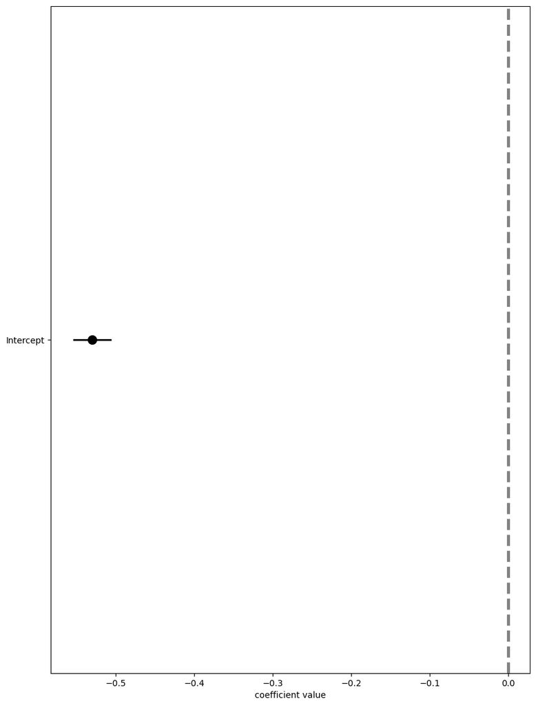

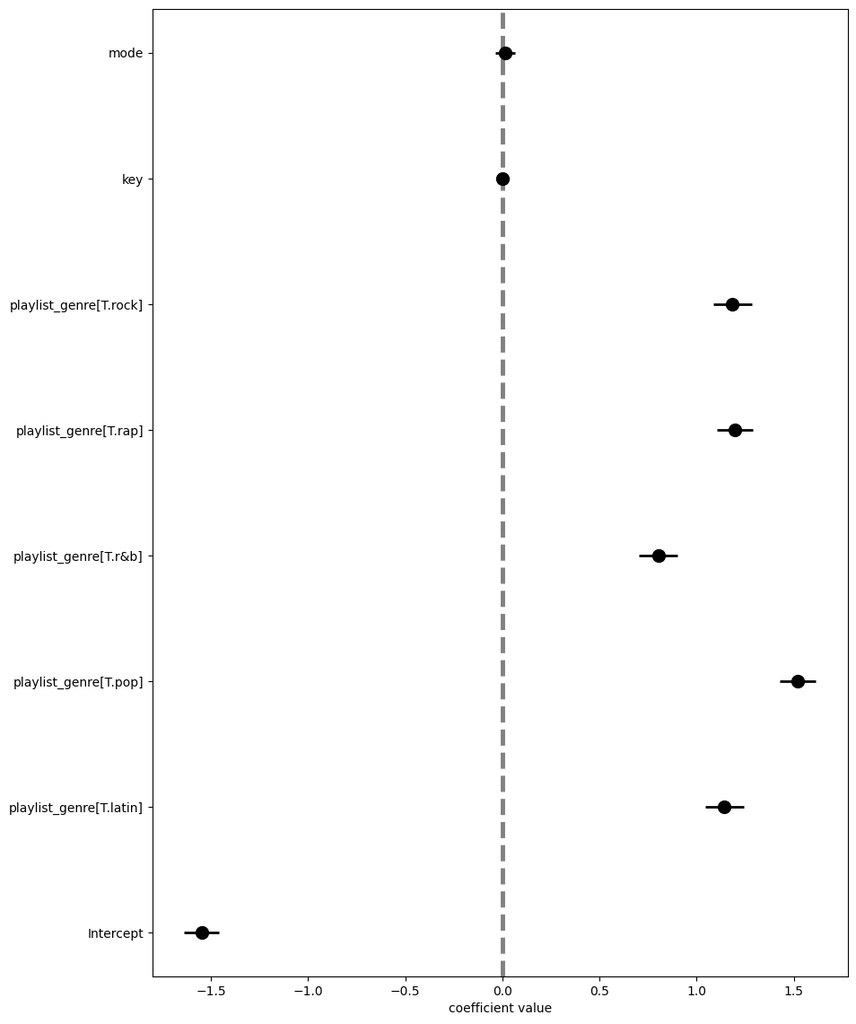

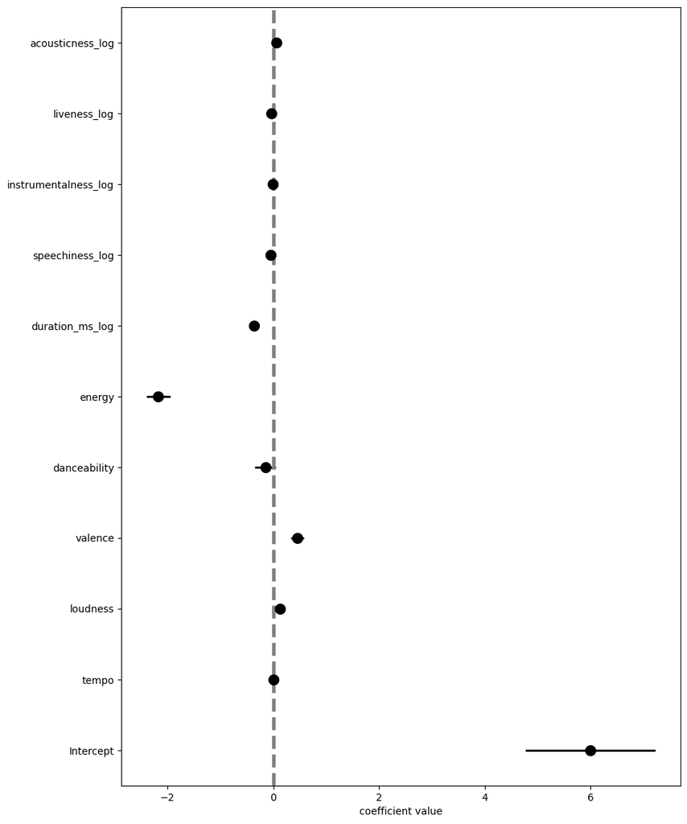

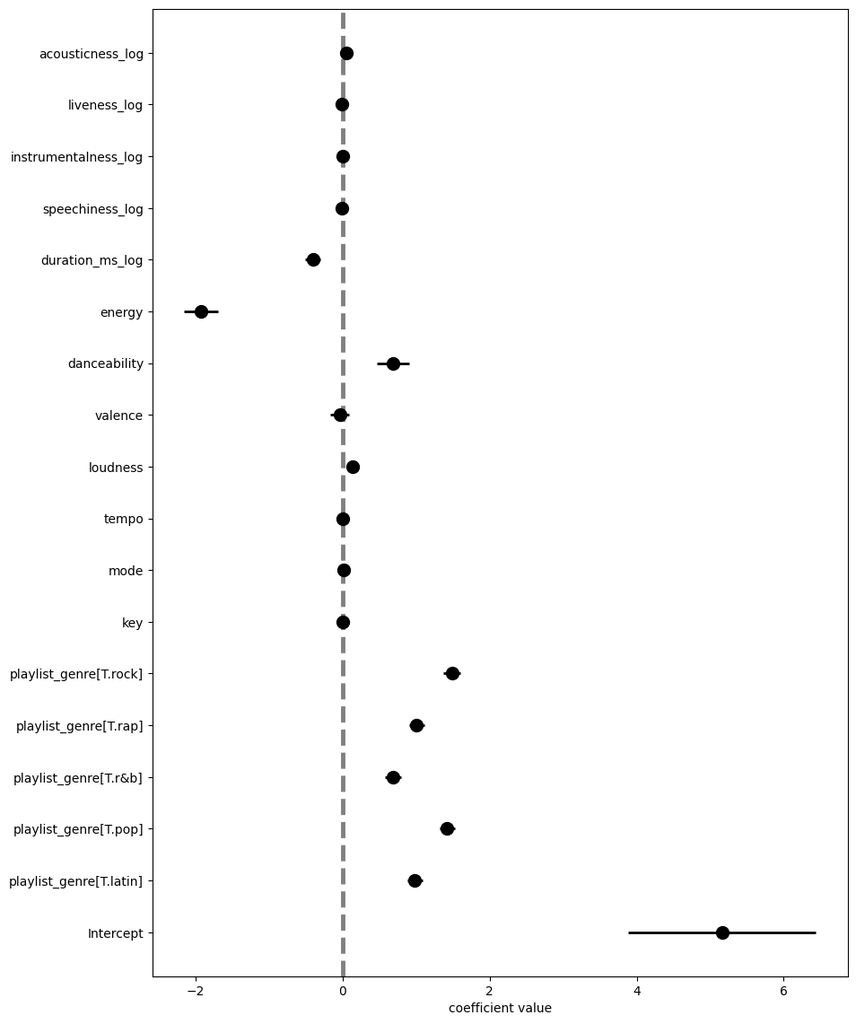

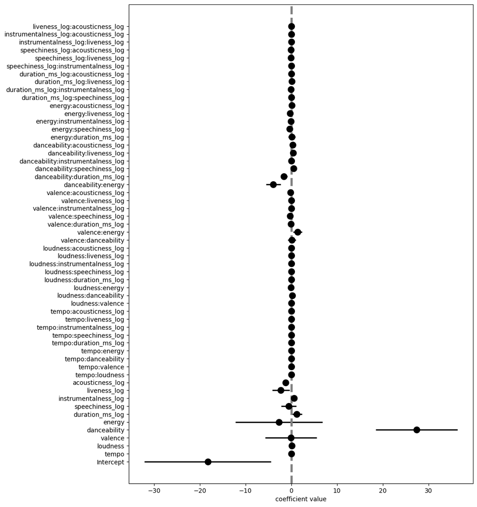

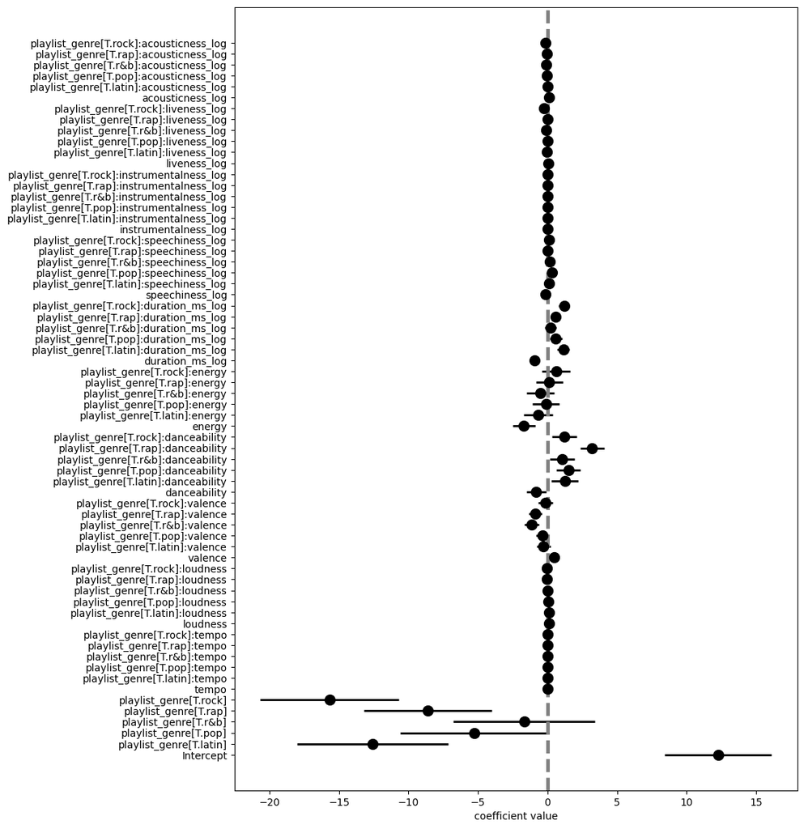

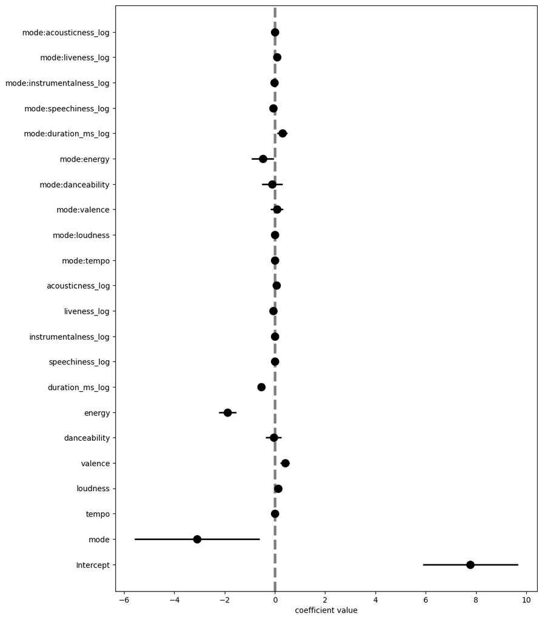

[figure not shown]

```python
for m in models:
    my_coefplot(m)
```

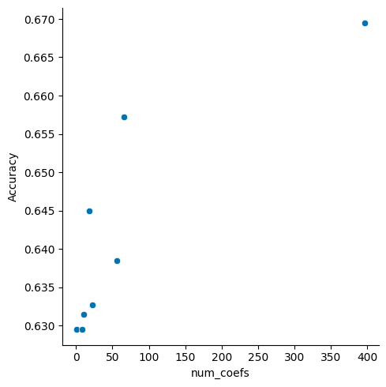

```python
sns.relplot(data = results_df, x='num_coefs', y='Accuracy', kind='scatter')

plt.show()
```

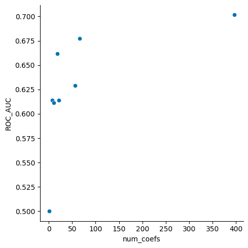

```python
sns.relplot(data = results_df, x='num_coefs', y='ROC_AUC', kind='scatter')

plt.show()
```

#### Best Performing Model

- **model_name**: 7
- **model_formula**: `y ~ playlist_genre * ( (tempo + loudness + valence + danceability + energy + duration_ms_log + speechiness_log + instrumentalness_log + liveness_log + acousticness_log)**2 + np.power(tempo,2) + np.power(loudness,2) + np.power(valence,2) + np.power(danceability,2) + np.power(energy,2) + np.power(duration_ms_log,2) + np.power(speechiness_log,2) + np.power(instrumentalness_log,2) + np.power(liveness_log,2) + np.power(acousticness_log,2))`
- **Accuracy Vs ROC** - In this case the model doesn't change between Accuracy Vs ROC. It is still model 7
- **No. of coefs**: 396
- The best model performs **better** than INTERCEPT-ONLY model

#### Visualize the entire ROC curve for each model

```python
def fit_logistic_make_roc(mod_name, a_formula, train_data):
    a_mod = smf.logit(formula=a_formula, data=train_data).fit()

    train_copy = train_data.copy()

    train_copy['pred_probability'] = a_mod.predict( train_data )

    fpr, tpr, threshold = roc_curve( train_data.y.to_numpy(), train_copy.pred_probability.to_numpy() )

    res_df = pd.DataFrame({'tpr': tpr,
                           'fpr': fpr,
                           'threshold': threshold})

    res_df['model_name'] = mod_name
    res_df['model_formula'] = a_formula

    return res_df
```

```python
roc_list = []

for m in range( len(formula_list) ):
    roc_list.append( fit_logistic_make_roc( m, formula_list[m], train_data=df))
```

```
Optimization terminated successfully.
         Current function value: 0.659223
         Iterations 4
Optimization terminated successfully.
         Current function value: 0.635441
         Iterations 5
Optimization terminated successfully.
         Current function value: 0.642106
         Iterations 5
Optimization terminated successfully.
         Current function value: 0.620351
         Iterations 6
Optimization terminated successfully.
         Current function value: 0.633988
         Iterations 6
Optimization terminated successfully.
         Current function value: 0.612935
         Iterations 7
Optimization terminated successfully.
         Current function value: 0.641314
         Iterations 5
Optimization terminated successfully.
         Current function value: 0.597308
         Iterations 15
```

```python
roc_df = pd.concat( roc_list, ignore_index=True )
roc_df.info()
```

```
<class 'pandas.core.frame.DataFrame'>
RangeIndex: 75759 entries, 0 to 75758
Data columns (total 5 columns):
 #   Column         Non-Null Count  Dtype
---  ------         --------------  -----
 0   tpr            75759 non-null  float64
 1   fpr            75759 non-null  float64
 2   threshold      75759 non-null  float64
 3   model_name     75759 non-null  int64
 4   model_formula  75759 non-null  object
dtypes: float64(3), int64(1), object(1)
memory usage: 2.9+ MB
```

```python
roc_df['model_name'] = roc_df.model_name.astype('category')
roc_df.info()
```

```
<class 'pandas.core.frame.DataFrame'>
RangeIndex: 75759 entries, 0 to 75758
Data columns (total 5 columns):
 #   Column         Non-Null Count  Dtype
---  ------         --------------  -----
 0   tpr            75759 non-null  float64
 1   fpr            75759 non-null  float64
 2   threshold      75759 non-null  float64
 3   model_name     75759 non-null  category
 4   model_formula  75759 non-null  object
dtypes: category(1), float64(3), object(1)
memory usage: 2.4+ MB
```

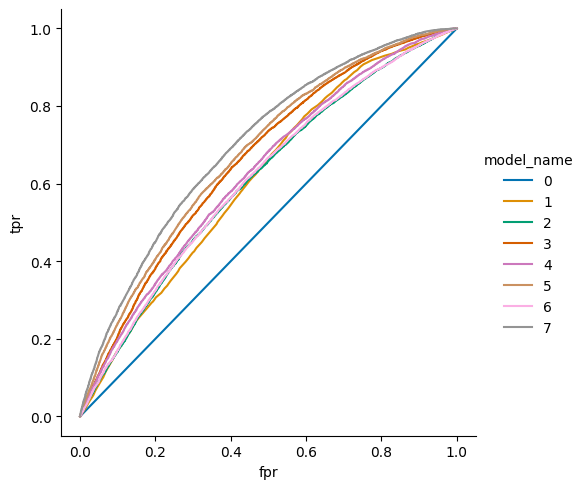

```python
sns.relplot(data = roc_df, x='fpr', y='tpr', hue='model_name',
            kind='line', estimator=None,)

plt.show()
```

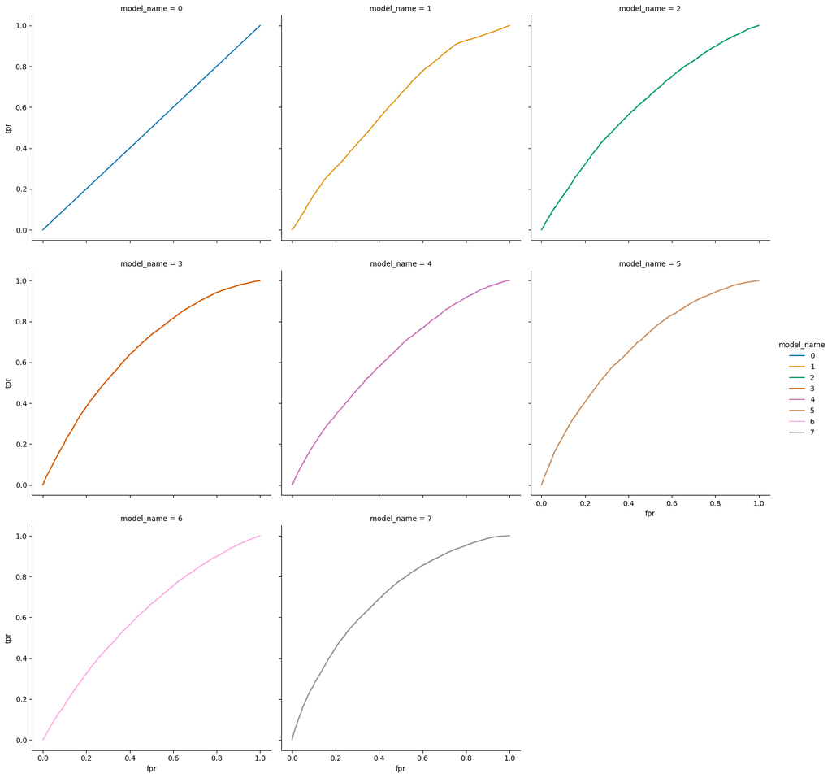

```python
sns.relplot(data = roc_df, x='fpr', y='tpr', hue='model_name',
            kind='line', estimator=None, col='model_name', col_wrap=3)

plt.show()
```

#### Identifying statistically significant features

```python
# Model with all features
model_all_feat = smf.logit(formula=formula_list[3], data=df).fit()
```

```
Optimization terminated successfully.
         Current function value: 0.620351
         Iterations 6
```

```python
print(model_all_feat.pvalues[model_all_feat.pvalues < 0.05].sort_values().to_string())
```

```
playlist_genre[T.pop]      2.617667e-184
playlist_genre[T.rock]     1.223407e-158
loudness                   5.572640e-108
playlist_genre[T.rap]       3.086667e-84
playlist_genre[T.latin]     5.867846e-78
energy                      3.397391e-60
playlist_genre[T.r&b]       2.052120e-35
Intercept                   6.860019e-16
acousticness_log            1.010851e-15
duration_ms_log             3.554137e-15
danceability                3.869361e-10
tempo                       1.036601e-06
```

```python
# Best performing model
model_best = smf.logit(formula=formula_list[7], data=df).fit()
```

```
Optimization terminated successfully.
         Current function value: 0.597308
         Iterations 15
```

```python
print(model_best.pvalues[model_best.pvalues < 0.05].sort_values().to_string())
```

```
playlist_genre[T.pop]:tempo:speechiness_log                 0.000038
playlist_genre[T.rap]:tempo:speechiness_log                 0.000046
playlist_genre[T.latin]:tempo:speechiness_log               0.000074
playlist_genre[T.pop]:np.power(loudness, 2)                 0.000110
playlist_genre[T.r&b]:tempo:speechiness_log                 0.000139
playlist_genre[T.rock]:danceability:instrumentalness_log    0.000164
tempo:speechiness_log                                       0.000210
duration_ms_log                                             0.000693
valence:instrumentalness_log                                0.000765
np.power(duration_ms_log, 2)                                0.000943
playlist_genre[T.rock]:tempo:valence                        0.001122
Intercept                                                   0.001265
playlist_genre[T.latin]:valence:instrumentalness_log        0.001375
playlist_genre[T.rock]:loudness:duration_ms_log             0.001454
loudness:duration_ms_log                                    0.001490
loudness                                                    0.001938
playlist_genre[T.rap]:valence:instrumentalness_log          0.001972
playlist_genre[T.rap]:loudness                              0.002020
playlist_genre[T.r&b]:loudness:valence                      0.002022
playlist_genre[T.rap]:valence:speechiness_log               0.002107
playlist_genre[T.rap]:loudness:duration_ms_log              0.002553
playlist_genre[T.latin]:np.power(valence, 2)                0.003008
playlist_genre[T.r&b]:valence:instrumentalness_log          0.003140
playlist_genre[T.pop]:danceability:acousticness_log         0.003765
playlist_genre[T.rap]:tempo:instrumentalness_log            0.004021
danceability:instrumentalness_log                           0.004088
playlist_genre[T.rap]:np.power(valence, 2)                  0.004557
playlist_genre[T.rock]:loudness                             0.005344
playlist_genre[T.rock]:energy:liveness_log                  0.005627
playlist_genre[T.pop]:danceability:instrumentalness_log     0.005915
playlist_genre[T.pop]:loudness:valence                      0.006003
playlist_genre[T.r&b]:tempo:valence                         0.006055
playlist_genre[T.latin]:loudness:duration_ms_log            0.006093
playlist_genre[T.rap]:danceability:instrumentalness_log     0.006162
playlist_genre[T.pop]:valence:instrumentalness_log          0.006614
playlist_genre[T.latin]:loudness                            0.007081
playlist_genre[T.rock]:energy:acousticness_log              0.007481
playlist_genre[T.rock]:valence:instrumentalness_log         0.007618
playlist_genre[T.pop]:tempo:valence                         0.007925
playlist_genre[T.rock]:danceability:acousticness_log        0.009008
```

[output cut: 27 more lines]

```
playlist_genre[T.r&b]:danceability:instrumentalness_log     0.030629
tempo:instrumentalness_log                                  0.031795
playlist_genre[T.pop]:valence:speechiness_log               0.033448
playlist_genre[T.r&b]:liveness_log:acousticness_log         0.037329
playlist_genre[T.latin]:liveness_log:acousticness_log       0.038067
playlist_genre[T.r&b]:valence:speechiness_log               0.038762
playlist_genre[T.rap]:np.power(loudness, 2)                 0.039736
playlist_genre[T.latin]:energy:acousticness_log             0.042226
playlist_genre[T.r&b]:loudness:duration_ms_log              0.042251
playlist_genre[T.rock]:liveness_log:acousticness_log        0.044431
loudness:danceability                                       0.044651
playlist_genre[T.rock]:valence:speechiness_log              0.045373
playlist_genre[T.latin]:tempo:valence                       0.046126
energy:liveness_log                                         0.047472
playlist_genre[T.pop]:speechiness_log                       0.047958
```

```python
# Second best performing model
model_5 = smf.logit(formula=formula_list[5], data=df).fit()
```

```
Optimization terminated successfully.
         Current function value: 0.612935
         Iterations 7
```

```python
print(model_5.pvalues[model_5.pvalues < 0.05].sort_values().to_string())
```

```
playlist_genre[T.rap]:danceability         4.200215e-14
Intercept                                  1.643470e-10
playlist_genre[T.rock]                     3.455261e-10
duration_ms_log                            8.318247e-10
playlist_genre[T.rock]:duration_ms_log     1.990475e-09
loudness                                   4.648723e-08
acousticness_log                           5.502261e-08
playlist_genre[T.rock]:acousticness_log    1.567145e-07
playlist_genre[T.latin]:duration_ms_log    1.896423e-07
playlist_genre[T.latin]                    3.817529e-06
playlist_genre[T.r&b]:valence              9.812608e-06
energy                                     2.493741e-05
playlist_genre[T.pop]:speechiness_log      1.232495e-04
playlist_genre[T.rap]                      1.789994e-04
playlist_genre[T.rap]:valence              2.230364e-04
playlist_genre[T.pop]:danceability         5.309010e-04
playlist_genre[T.rock]:liveness_log        7.486233e-04
playlist_genre[T.rap]:duration_ms_log      1.480463e-03
playlist_genre[T.latin]:loudness           3.336297e-03
playlist_genre[T.pop]:duration_ms_log      5.264044e-03
playlist_genre[T.pop]:loudness             6.202401e-03
playlist_genre[T.rock]:danceability        8.064623e-03
playlist_genre[T.latin]:danceability       1.018031e-02
playlist_genre[T.rock]:loudness            1.172571e-02
valence                                    1.594447e-02
playlist_genre[T.r&b]:acousticness_log     1.833355e-02
playlist_genre[T.r&b]:danceability         1.993026e-02
danceability                               2.043862e-02
playlist_genre[T.pop]:acousticness_log     4.710784e-02
playlist_genre[T.pop]                      4.941518e-02
speechiness_log                            4.945149e-02
```

🛸 **loudness, duration_ms_log, playlist_genre** are the significant features

## E. Models: Predictions

```python
df.describe(include=object)
```

|  | playlist_genre |
| --- | --- |
| count | 28356 |
| unique | 6 |
| top | rap |
| freq | 5401 |

```python
df.describe()
```

|  | danceability | energy | key | loudness | mode | speechiness | acousticness | instrumentalness | liveness | valence | tempo | duration_ms | speechiness_log | acousticness_log | instrumentalness_log | liveness_log | duration_ms_log | y |
| --- | --- | --- | --- | --- | --- | --- | --- | --- | --- | --- | --- | --- | --- | --- | --- | --- | --- | --- |
| count | 28356.000000 | 28356.000000 | 28356.000000 | 28356.000000 | 28356.000000 | 28356.000000 | 28356.000000 | 28356.000000 | 28356.000000 | 28356.000000 | 28356.00000 | 28356.000000 | 28356.000000 | 28356.000000 | 28356.000000 | 28356.000000 | 28356.000000 | 28356.000000 |
| mean | 0.653372 | 0.698388 | 5.368000 | -6.817696 | 0.565489 | 0.107954 | 0.177176 | 0.091117 | 0.190958 | 0.510387 | 120.95618 | 226575.967026 | -2.562168 | -3.044614 | -4.198872 | -1.908728 | 12.296231 | 0.370504 |
| std | 0.145785 | 0.183503 | 3.613904 | 3.036243 | 0.495701 | 0.102556 | 0.222803 | 0.232548 | 0.155894 | 0.234340 | 26.95456 | 61078.450819 | 0.775959 | 2.225113 | 4.681524 | 0.688639 | 0.264864 | 0.482948 |
| min | 0.000000 | 0.000175 | 0.000000 | -46.448000 | 0.000000 | 0.000000 | 0.000000 | 0.000000 | 0.000000 | 0.000000 | 0.00000 | 4000.000000 | -3.798694 | -13.479038 | -13.815511 | -4.671310 | 8.294050 | 0.000000 |
| 25% | 0.561000 | 0.579000 | 2.000000 | -8.309250 | 0.000000 | 0.041000 | 0.014375 | 0.000000 | 0.092600 | 0.329000 | 99.97200 | 187742.000000 | -3.194183 | -4.240527 | -8.381789 | -2.379466 | 12.142824 | 0.000000 |
| 50% | 0.670000 | 0.722000 | 6.000000 | -6.261000 | 1.000000 | 0.062600 | 0.079700 | 0.000021 | 0.127000 | 0.512000 | 121.99300 | 216933.000000 | -2.770990 | -2.529486 | -1.937942 | -2.063568 | 12.287344 | 0.000000 |
| 75% | 0.760000 | 0.843000 | 9.000000 | -4.709000 | 1.000000 | 0.133000 | 0.260000 | 0.006570 | 0.249000 | 0.695000 | 133.99900 | 254975.250000 | -2.017406 | -1.347074 | 0.000000 | -1.390302 | 12.448922 | 1.000000 |
| max | 0.983000 | 1.000000 | 11.000000 | 1.275000 | 1.000000 | 0.918000 | 0.994000 | 0.994000 | 0.996000 | 0.991000 | 239.44000 | 517810.000000 | 0.000000 | 0.000000 | 0.000000 | 0.000000 | 13.157364 | 1.000000 |

```python
input_grid = pd.DataFrame([(playlist_genre, danceability, energy, key, loudness, mode, valence, tempo, speechiness_log, acousticness_log, instrumentalness_log, liveness_log, duration_ms_log)
                           for playlist_genre in df.playlist_genre.unique()
                           for danceability in [df.danceability.mean()]
                           for energy in [df.energy.mean()]
                           for key in df.key.mode()
                           for loudness in np.linspace(df.loudness.min(), df.loudness.max(), num=5)
                           for mode in df['mode'].mode()
                           for valence in [df.valence.mean()]
                           for tempo in [df.tempo.mean()]
                           for speechiness_log in [df.speechiness_log.mean()]
                           for acousticness_log in [df.acousticness_log.mean()]
                           for instrumentalness_log in [df.instrumentalness_log.mean()]
                           for liveness_log in [df.liveness_log.mean()]
                           for duration_ms_log in np.linspace(df.duration_ms_log.min(), df.duration_ms_log.max(), num=101)
                          ],
                          columns=['playlist_genre', 'danceability', 'energy', 'key', 'loudness', 'mode', 'valence', 'tempo', 'speechiness_log', 'acousticness_log', 'instrumentalness_log', 'liveness_log', 'duration_ms_log'])
```

```python
input_grid.nunique()
```

```
playlist_genre            6
danceability              1
energy                    1
key                       1
loudness                  5
mode                      1
valence                   1
tempo                     1
speechiness_log           1
acousticness_log          1
instrumentalness_log      1
liveness_log              1
duration_ms_log         101
dtype: int64
```

```python
dfviz = input_grid.copy()
```

```python
dfviz['pred_probability_all'] = model_all_feat.predict(input_grid)
```

```python
dfviz['pred_probability_best'] = model_best.predict(input_grid)
```

```python
dfviz['pred_probability_5'] = model_5.predict(input_grid)
```

### Visualize predict probability using the formula with ALL features

#### Plot

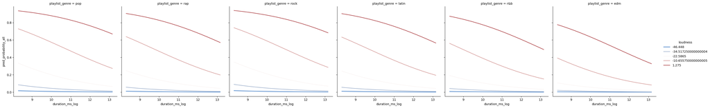

```python
g = sns.relplot(data = dfviz, x='duration_ms_log', y='pred_probability_all',
                hue='loudness',
                col='playlist_genre',
                kind='line',
                palette='vlag', estimator=None, units='loudness')

plt.show()
```

```python
model_all_feat.pvalues < 0.05
```

```
Intercept                   True
playlist_genre[T.latin]     True
playlist_genre[T.pop]       True
playlist_genre[T.r&b]       True
playlist_genre[T.rap]       True
playlist_genre[T.rock]      True
key                        False
mode                       False
tempo                       True
loudness                    True
valence                    False
danceability                True
energy                      True
duration_ms_log             True
speechiness_log            False
instrumentalness_log       False
liveness_log               False
acousticness_log            True
dtype: bool
```

#### Interpretation

👉 The above plot shows that regardless of genre shorter and louder songs tend to be more popular

### Visualize predict probability using the BEST model

#### Plot

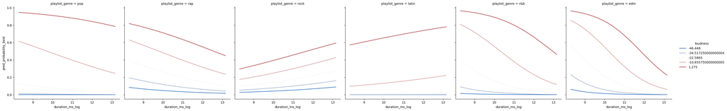

```python
g= sns.relplot(data = dfviz, x='duration_ms_log', y='pred_probability_best',
               hue='loudness',
               col='playlist_genre',
               kind='line',
               palette='vlag', estimator=None, units='loudness')

plt.show()
```

#### Interpretation

👉 Predicted Probability depends on both `loudness` and `duration_ms`

👉 Loudness consistently boosts predicted probability

👉 The effect of duration on predicted probability differs based on genre

### Visualize predict probability using the Second Best model

#### Plot

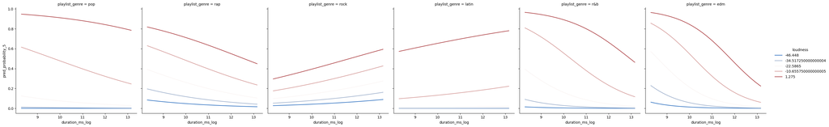

```python
g= sns.relplot(data = dfviz, x='duration_ms_log', y='pred_probability_5',
               hue='loudness',
               col='playlist_genre',
               kind='line',
               palette='vlag', estimator=None, units='loudness')

plt.show()
```

#### Interpretation

👉 Predicted Probability depends on both `loudness` and `duration_ms`

👉 Loudness consistently boosts predicted probability

👉 The effect of duration on predicted probability differs based on genre

## F. Models: Performance and Validation

```python
kf = StratifiedKFold(n_splits=5, shuffle=True, random_state=101)
kf.get_n_splits()
```

```
5
```

```python
input_names = df.drop(columns=['y']).copy().columns.to_list()
input_names
```

```
['playlist_genre',
 'danceability',
 'energy',
 'key',
 'loudness',
 'mode',
 'speechiness',
 'acousticness',
 'instrumentalness',
 'liveness',
 'valence',
 'tempo',
 'duration_ms',
 'speechiness_log',
 'acousticness_log',
 'instrumentalness_log',
 'liveness_log',
 'duration_ms_log']
```

```python
output_name = 'y'
```

```python
def train_and_test_logistic_with_cv(mod_name, a_formula, data_df, x_names, y_name, cv, threshold=0.5):
    # separate the inputs and output
    input_df = data_df.loc[ :, x_names ].copy()

    # initialize the performance metric storage lists
    train_res = []
    test_res = []

    # SPLIT the data and iterate over the folds
    for train_id, test_id in cv.split( input_df.to_numpy(), data_df[ y_name ].to_numpy() ):
        # subset the training and test splits within each fold
        train_data = data_df.iloc[ train_id, :].copy()
        test_data = data_df.iloc[ test_id, :].copy()

        # FIT the model on the TRAINING data within the current FOLD
        a_mod = smf.logit(formula=a_formula, data=train_data).fit()

        # PREDICT the TRAINING within each FOLD
        train_copy = train_data.copy()
        train_copy['pred_probability'] = a_mod.predict( train_data )
        train_copy['pred_class'] = np.where( train_copy.pred_probability > threshold, 1, 0 )

        # PREDICT the TESTING within each FOLD
        test_copy = test_data.copy()
        test_copy['pred_probability'] = a_mod.predict( test_data )
        test_copy['pred_class'] = np.where( test_copy.pred_probability > threshold, 1, 0)

        # calculate the PERFORMANCE METRIC on the TRAINING SET within the FOLD
        train_res.append( np.mean( train_copy[ y_name ] == train_copy.pred_class ) )

        # calculate the PERFORMANCE METRIC on the TESTING SET within the FOLD
        test_res.append( np.mean( test_copy[ y_name ] == test_copy.pred_class ) )

    # book keeping to store the results
    train_df = pd.DataFrame({'Accuracy': train_res})
    train_df['from_set'] = 'training'
    train_df['fold_id'] = train_df.index + 1

    test_df = pd.DataFrame({'Accuracy': test_res})
    test_df['from_set'] = 'testing'
    test_df['fold_id'] = test_df.index + 1

    # combine the splits together
    res_df = pd.concat([train_df, test_df], ignore_index=True)

    # add information about the model
    res_df['model_name'] = mod_name
    res_df['model_formula'] = a_formula
    res_df['num_coefs'] = len( a_mod.params )
    res_df['threshold'] = threshold

    return res_df
```

```python
train_and_test_logistic_with_cv(0, formula_list[3], data_df=df, x_names=input_names, y_name=output_name, cv=kf)
```

```
Optimization terminated successfully.
         Current function value: 0.619315
         Iterations 6
Optimization terminated successfully.
         Current function value: 0.620069
         Iterations 6
Optimization terminated successfully.
         Current function value: 0.619864
         Iterations 6
Optimization terminated successfully.
         Current function value: 0.621844
         Iterations 5
Optimization terminated successfully.
         Current function value: 0.620260
         Iterations 6
```

|  | Accuracy | from_set | fold_id | model_name | model_formula | num_coefs | threshold |
| --- | --- | --- | --- | --- | --- | --- | --- |
| 0 | 0.646755 | training | 1 | 0 | y ~ playlist_genre + key + mode + tempo + loud... | 18 | 0.5 |
| 1 | 0.644214 | training | 2 | 0 | y ~ playlist_genre + key + mode + tempo + loud... | 18 | 0.5 |
| 2 | 0.646771 | training | 3 | 0 | y ~ playlist_genre + key + mode + tempo + loud... | 18 | 0.5 |
| 3 | 0.642760 | training | 4 | 0 | y ~ playlist_genre + key + mode + tempo + loud... | 18 | 0.5 |
| 4 | 0.645228 | training | 5 | 0 | y ~ playlist_genre + key + mode + tempo + loud... | 18 | 0.5 |
| 5 | 0.639986 | testing | 1 | 0 | y ~ playlist_genre + key + mode + tempo + loud... | 18 | 0.5 |
| 6 | 0.646623 | testing | 2 | 0 | y ~ playlist_genre + key + mode + tempo + loud... | 18 | 0.5 |
| 7 | 0.641157 | testing | 3 | 0 | y ~ playlist_genre + key + mode + tempo + loud... | 18 | 0.5 |
| 8 | 0.652971 | testing | 4 | 0 | y ~ playlist_genre + key + mode + tempo + loud... | 18 | 0.5 |
| 9 | 0.642920 | testing | 5 | 0 | y ~ playlist_genre + key + mode + tempo + loud... | 18 | 0.5 |

```python
train_and_test_logistic_with_cv(0, formula_list[5], data_df=df, x_names=input_names, y_name=output_name, cv=kf)
```

```
Optimization terminated successfully.
         Current function value: 0.611040
         Iterations 7
Optimization terminated successfully.
         Current function value: 0.612808
         Iterations 7
Optimization terminated successfully.
         Current function value: 0.612398
         Iterations 7
Optimization terminated successfully.
         Current function value: 0.614464
         Iterations 7
Optimization terminated successfully.
         Current function value: 0.612425
         Iterations 7
```

|  | Accuracy | from_set | fold_id | model_name | model_formula | num_coefs | threshold |
| --- | --- | --- | --- | --- | --- | --- | --- |
| 0 | 0.658349 | training | 1 | 0 | y ~ playlist_genre * (tempo + loudness + valen... | 66 | 0.5 |
| 1 | 0.656557 | training | 2 | 0 | y ~ playlist_genre * (tempo + loudness + valen... | 66 | 0.5 |
| 2 | 0.657791 | training | 3 | 0 | y ~ playlist_genre * (tempo + loudness + valen... | 66 | 0.5 |
| 3 | 0.653868 | training | 4 | 0 | y ~ playlist_genre * (tempo + loudness + valen... | 66 | 0.5 |
| 4 | 0.658585 | training | 5 | 0 | y ~ playlist_genre * (tempo + loudness + valen... | 66 | 0.5 |
| 5 | 0.651622 | testing | 1 | 0 | y ~ playlist_genre * (tempo + loudness + valen... | 66 | 0.5 |
| 6 | 0.655264 | testing | 2 | 0 | y ~ playlist_genre * (tempo + loudness + valen... | 66 | 0.5 |
| 7 | 0.650150 | testing | 3 | 0 | y ~ playlist_genre * (tempo + loudness + valen... | 66 | 0.5 |
| 8 | 0.664962 | testing | 4 | 0 | y ~ playlist_genre * (tempo + loudness + valen... | 66 | 0.5 |
| 9 | 0.653148 | testing | 5 | 0 | y ~ playlist_genre * (tempo + loudness + valen... | 66 | 0.5 |

```python
train_and_test_logistic_with_cv(0, formula_list[7], data_df=df, x_names=input_names, y_name=output_name, cv=kf)
```

```
Optimization terminated successfully.
         Current function value: 0.593297
         Iterations 16
Optimization terminated successfully.
         Current function value: 0.596232
         Iterations 16
Optimization terminated successfully.
         Current function value: 0.595761
         Iterations 16
Optimization terminated successfully.
         Current function value: 0.596898
         Iterations 16
Optimization terminated successfully.
         Current function value: 0.595371
         Iterations 15
```

|  | Accuracy | from_set | fold_id | model_name | model_formula | num_coefs | threshold |
| --- | --- | --- | --- | --- | --- | --- | --- |
| 0 | 0.676688 | training | 1 | 0 | y ~ playlist_genre * ( (tempo + loudness + val... | 396 | 0.5 |
| 1 | 0.670267 | training | 2 | 0 | y ~ playlist_genre * ( (tempo + loudness + val... | 396 | 0.5 |
| 2 | 0.672868 | training | 3 | 0 | y ~ playlist_genre * ( (tempo + loudness + val... | 396 | 0.5 |
| 3 | 0.671942 | training | 4 | 0 | y ~ playlist_genre * ( (tempo + loudness + val... | 396 | 0.5 |
| 4 | 0.673132 | training | 5 | 0 | y ~ playlist_genre * ( (tempo + loudness + val... | 396 | 0.5 |
| 5 | 0.651798 | testing | 1 | 0 | y ~ playlist_genre * ( (tempo + loudness + val... | 396 | 0.5 |
| 6 | 0.658614 | testing | 2 | 0 | y ~ playlist_genre * ( (tempo + loudness + val... | 396 | 0.5 |
| 7 | 0.659672 | testing | 3 | 0 | y ~ playlist_genre * ( (tempo + loudness + val... | 396 | 0.5 |
| 8 | 0.661435 | testing | 4 | 0 | y ~ playlist_genre * ( (tempo + loudness + val... | 396 | 0.5 |
| 9 | 0.658438 | testing | 5 | 0 | y ~ playlist_genre * ( (tempo + loudness + val... | 396 | 0.5 |

```python
results_list = []

for m in range( len(formula_list) ):
    print( '-- Formula ID %d --' % m )

    try:
        results_list.append( train_and_test_logistic_with_cv(m, formula_list[m], data_df=df, x_names=input_names, y_name=output_name, cv=kf) )
    except:
        # what happens if there is an ERROR
        print( ' !!! Formula ID %d could NOT fit !!! ' % m)
```

```
-- Formula ID 0 --
Optimization terminated successfully.
         Current function value: 0.659211
         Iterations 4
Optimization terminated successfully.
         Current function value: 0.659226
         Iterations 4
Optimization terminated successfully.
         Current function value: 0.659226
         Iterations 4
Optimization terminated successfully.
         Current function value: 0.659226
         Iterations 4
Optimization terminated successfully.
         Current function value: 0.659226
         Iterations 4
-- Formula ID 1 --
Optimization terminated successfully.
         Current function value: 0.635259
         Iterations 5
Optimization terminated successfully.
         Current function value: 0.635084
         Iterations 5
Optimization terminated successfully.
         Current function value: 0.634771
         Iterations 5
Optimization terminated successfully.
         Current function value: 0.636872
         Iterations 5
Optimization terminated successfully.
         Current function value: 0.635024
         Iterations 5
-- Formula ID 2 --
Optimization terminated successfully.
         Current function value: 0.641017
         Iterations 5
Optimization terminated successfully.
         Current function value: 0.642256
         Iterations 5
Optimization terminated successfully.
```

[output cut: 73 more lines]

```
Optimization terminated successfully.
         Current function value: 0.593297
         Iterations 16
Optimization terminated successfully.
         Current function value: 0.596232
         Iterations 16
Optimization terminated successfully.
         Current function value: 0.595761
         Iterations 16
Optimization terminated successfully.
         Current function value: 0.596898
         Iterations 16
Optimization terminated successfully.
         Current function value: 0.595371
         Iterations 15
```

```python
cv_results = pd.concat(results_list, ignore_index=True )
cv_results
```

|  | Accuracy | from_set | fold_id | model_name | model_formula | num_coefs | threshold |
| --- | --- | --- | --- | --- | --- | --- | --- |
| 0 | 0.629519 | training | 1 | 0 | y ~ 1 | 1 | 0.5 |
| 1 | 0.629491 | training | 2 | 0 | y ~ 1 | 1 | 0.5 |
| 2 | 0.629491 | training | 3 | 0 | y ~ 1 | 1 | 0.5 |
| 3 | 0.629491 | training | 4 | 0 | y ~ 1 | 1 | 0.5 |
| 4 | 0.629491 | training | 5 | 0 | y ~ 1 | 1 | 0.5 |
| ... | ... | ... | ... | ... | ... | ... | ... |
| 75 | 0.651798 | testing | 1 | 7 | y ~ playlist_genre * ( (tempo + loudness + val... | 396 | 0.5 |
| 76 | 0.658614 | testing | 2 | 7 | y ~ playlist_genre * ( (tempo + loudness + val... | 396 | 0.5 |
| 77 | 0.659672 | testing | 3 | 7 | y ~ playlist_genre * ( (tempo + loudness + val... | 396 | 0.5 |
| 78 | 0.661435 | testing | 4 | 7 | y ~ playlist_genre * ( (tempo + loudness + val... | 396 | 0.5 |
| 79 | 0.658438 | testing | 5 | 7 | y ~ playlist_genre * ( (tempo + loudness + val... | 396 | 0.5 |

80 rows × 7 columns

```python
cv_results.model_name.value_counts()
```

```
model_name
0    10
1    10
2    10
3    10
4    10
5    10
6    10
7    10
Name: count, dtype: int64
```

```python
cv_results['model_name'] = cv_results['model_name'].astype('category')
```

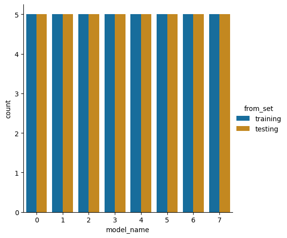

```python
sns.catplot(data = cv_results, x='model_name', hue='from_set', kind='count')

plt.show()
```

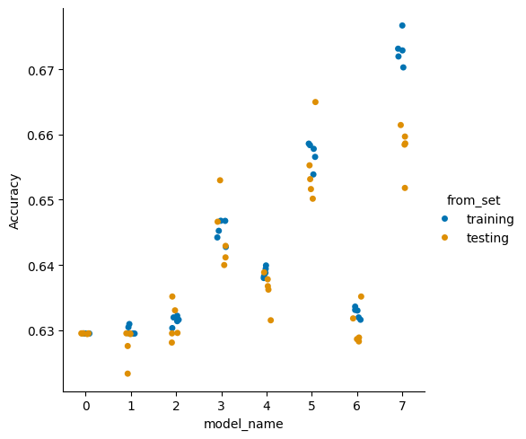

```python
sns.catplot(data = cv_results, x='model_name', y='Accuracy', hue='from_set')

plt.show()
```

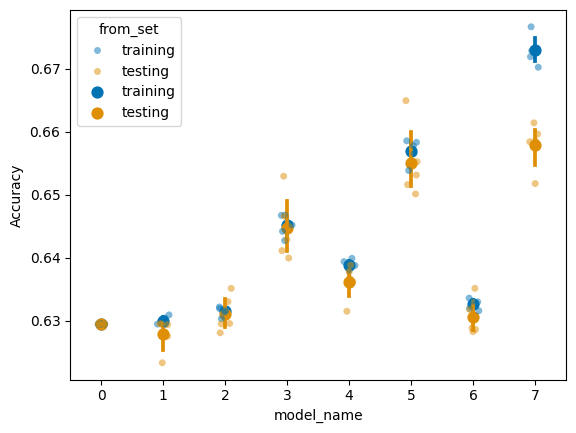

```python
fig, ax = plt.subplots()

sns.stripplot(data = cv_results, x='model_name', y='Accuracy', hue='from_set', alpha=0.5, ax=ax)

sns.pointplot(data = cv_results, x='model_name', y='Accuracy', hue='from_set', linestyle='none', ax=ax)

plt.show()
```

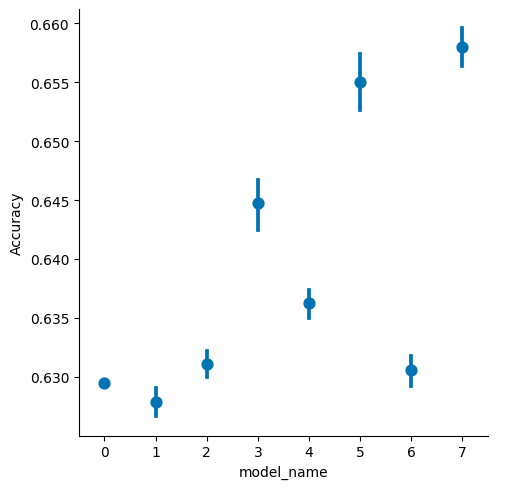

```python
sns.catplot(data = cv_results.loc[ cv_results.from_set == 'testing', :],
            x='model_name', y='Accuracy', kind='point', linestyle='none',
            errorbar=('ci', 68))

plt.show()
```

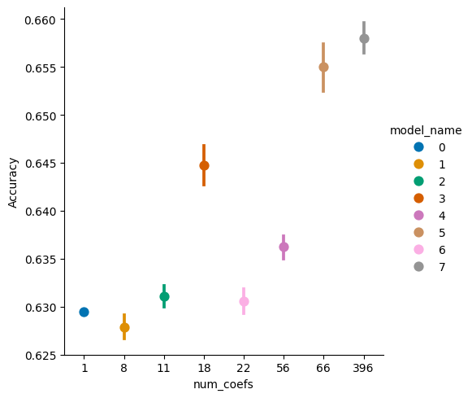

```python
sns.catplot(data = cv_results.loc[ cv_results.from_set == 'testing', :],
            x='num_coefs', y='Accuracy', kind='point', linestyle='none',
            hue='model_name',
            errorbar=('ci', 68))

plt.show()
```

### Model Selection

🌟 Based on the above POINT PLOT, **Model 5** is the new **BEST model** because it has lesser coefficients and within the margin of error of the previous best model Model 7 🌟

```python
best_model = smf.logit( formula=formula_list[5], data=df).fit()
```

```
Optimization terminated successfully.
         Current function value: 0.612935
         Iterations 7
```

```python
best_model.pvalues < 0.05
```

```
Intercept                                    True
playlist_genre[T.latin]                      True
playlist_genre[T.pop]                        True
playlist_genre[T.r&b]                       False
playlist_genre[T.rap]                        True
                                            ...
playlist_genre[T.latin]:acousticness_log    False
playlist_genre[T.pop]:acousticness_log       True
playlist_genre[T.r&b]:acousticness_log       True
playlist_genre[T.rap]:acousticness_log      False
playlist_genre[T.rock]:acousticness_log      True
Length: 66, dtype: bool
```

```python
dfviz['pred_probability'] = best_model.predict( input_grid )
```

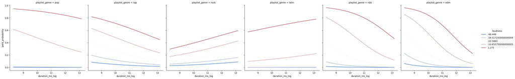

```python
g= sns.relplot(data = dfviz, x='duration_ms_log', y='pred_probability',
               hue='loudness',
               col='playlist_genre',
               kind='line',
               palette='vlag', estimator=None, units='loudness')

plt.show()
```